# Applied Machine Learning Project

## 1. Dataset (including citation of source and acknowledgment)

**Dataset Acknowledgment:**

UCI, 2014:German Credit Risk, 8.24. Database: Open Database, access date (31-10-2022), URL: https://www.kaggle.com/datasets/uciml/german-credit

```
- Build and train classification and/or regression models from the dataset in any suitable programming environment of your choosing (e.g., MATLAB) using three machine learning techniques of your choice.

- Justify the rationale behind the choice of your dataset, machine learning techniques, and programming environment.

- Compare and contrast the performance of the three machine learning techniques in terms of prediction or validation accuracy, training time, prediction speed, R-squared values, MSE values, and transparency (as may be applicable).

- Analyse the error matrices, the ROCs (and AUCs) for all three methods (as may be applicable).

- Comment on how the hyperparameters (if any) are tuned or optimized (if applicable) to enhance the built/trained models.

- Submit a report showing the work carried out. Report like what u do after every module.
```

## Insightful approach to assist me while building my model

```
- Is the data normally distributed or skewed?
- What's the gender characteristics?
- Does the Age good indicator to measure the Risk Level vs Credit amount?
- What's the correlation between the features of the dataframe?
```

[output not shown]

## 2. Definition and Justification of Problem According to the Dataset: Classification Problem and/or Regression Problem

Defination of the classification problem according to the dataset:

We have 1000 observations for customers and we want to classify the cutsomers based on dependent variable, so the bank will be able to assess the risk of the applications. We want to identify which users have higher risk level than normal based on their data [Age, Gender, Job Skills, Housing, Saving account, Checking account, Duration, Purpose of the loan].

My approach is the following:

```
1. Explore the raw data then convert it into a dataframe.

2. Wrangle the dataframe, and investigate the missing data, outliers, highlight the statistical inputs.

3. Data Exploration; create essential graphs to identify the characteristics of each variable in the dataframe.

4. Handle the missing data, usually it can be executed by using one of the imputation methods where to replace the missing variables with (mean > if the data is normally distributed - or mode/median > if the data is skewed)
I have decided to use machine learning in identifying the missing variables, beacuse it's more accurate and I will have the chance to implement what I have learned in this course. I couldn't done this step alone and I have included the books I have used in my approach as well as the academic papers from IEEE Xplore in the bottom of this file.

5. Classification three techniques which are [Logistic Regression - Random Forest - Support Vector Machines] including the statistical aspect behind it.

6. Comaprison between the three techniques where I use different methods such as ROC Curve, Classification Report, Confusion Matrix {Error Matrix}, AUC - Precision - Recall Ratios.

7. Final conclusion.
```

```python
# import the required libraries:

import pandas as pd
import numpy as np
import matplotlib.pyplot as plt
import seaborn as sns
from sklearn import preprocessing
from sklearn.preprocessing import OneHotEncoder
from sklearn.neighbors import KNeighborsClassifier
```

```python
# import the dataset:

df = pd.read_csv("german_credit_data.csv")
df.drop("Unnamed: 0", axis=1, inplace=True)
df.head(2)
```

|  | Age | Sex | Job | Housing | Saving accounts | Checking account | Credit amount | Duration | Purpose |
| --- | --- | --- | --- | --- | --- | --- | --- | --- | --- |
| 0 | 67 | male | 2 | own | NaN | little | 1169 | 6 | radio/TV |
| 1 | 22 | female | 2 | own | little | moderate | 5951 | 48 | radio/TV |

```python
df.info()
```

```
<class 'pandas.core.frame.DataFrame'>
RangeIndex: 1000 entries, 0 to 999
Data columns (total 9 columns):
 #   Column            Non-Null Count  Dtype
---  ------            --------------  -----
 0   Age               1000 non-null   int64
 1   Sex               1000 non-null   object
 2   Job               1000 non-null   int64
 3   Housing           1000 non-null   object
 4   Saving accounts   817 non-null    object
 5   Checking account  606 non-null    object
 6   Credit amount     1000 non-null   int64
 7   Duration          1000 non-null   int64
 8   Purpose           1000 non-null   object
dtypes: int64(4), object(5)
memory usage: 70.4+ KB
```

```python
round(df.describe(),2)
```

|  | Age | Job | Credit amount | Duration |
| --- | --- | --- | --- | --- |
| count | 1000.00 | 1000.00 | 1000.00 | 1000.00 |
| mean | 35.55 | 1.90 | 3271.26 | 20.90 |
| std | 11.38 | 0.65 | 2822.74 | 12.06 |
| min | 19.00 | 0.00 | 250.00 | 4.00 |
| 25% | 27.00 | 2.00 | 1365.50 | 12.00 |
| 50% | 33.00 | 2.00 | 2319.50 | 18.00 |
| 75% | 42.00 | 2.00 | 3972.25 | 24.00 |
| max | 75.00 | 3.00 | 18424.00 | 72.00 |

```python
round(df.corr(),2)
```

|  | Age | Job | Credit amount | Duration |
| --- | --- | --- | --- | --- |
| Age | 1.00 | 0.02 | 0.03 | -0.04 |
| Job | 0.02 | 1.00 | 0.29 | 0.21 |
| Credit amount | 0.03 | 0.29 | 1.00 | 0.62 |
| Duration | -0.04 | 0.21 | 0.62 | 1.00 |

## 3. Data Pre-processing and Feature Extraction: Identification of Predictors, Categories and Targets, Handling Noisy Data and Missing Data, Others

**Summarized Decription the steps here (I will explain them accordingly down below step by step)**

```
- Check the missing data then replace the NaN values with Zero in order to fill them later properly.
- Change the D-type of the variables since most of them are labeled with "object" type.
- Label Encoding the variables such as "Gender & Job"
```

### 3.1 Checking the missing data then replace them with zeros

```python
#Checking the NA values in the dataset

df.isna().sum()
```

```
Age                   0
Sex                   0
Job                   0
Housing               0
Saving accounts     183
Checking account    394
Credit amount         0
Duration              0
Purpose               0
dtype: int64
```

```python
# replace NA with zeros

df['Saving accounts'] = df['Saving accounts'].fillna(0, inplace=False)
df['Checking account'] = df['Checking account'].fillna(0, inplace=False)
```

### 3.2 Change the D-type for Executing Feature Engineering Technqiues

```python
# Convert the next variables into string type in order to apply Label Encoding later

df['Checking account'] = df['Checking account'].astype('string')
df['Saving accounts'] = df["Saving accounts"].astype("string")
df["Purpose"] = df["Purpose"].astype("string")
```

### 3.3 Implement Feature Engineering (Label Encoding) Technique

Label Encoding (LE) is an insipiring method to convert the variables into numeric variables but in order to do that, first we need to understand the variables dimension and values.

```
- Odinarl Data Type: BSc - Msc - PHD "more like ranking"

- Nominal Data: Gender Binary Data: Yes/No
```

**So in the next section all the variables will be converted into numeric values using LE method.**

Reference:

B. -B. Jia and M. -L. Zhang, "Multi-Dimensional Classification via Decomposed Label Encoding," in IEEE Transactions on Knowledge and Data Engineering, doi: 10.1109/TKDE.2021.3100436.

```python
# Since Sex variable & Housing are ordinarl variables then I will apply Encoding Labelling technique on both of
#them, because it sutis them best

le = preprocessing.LabelEncoder()

df['Housing'] = le.fit_transform(df['Housing'])
df["Gender"] = le.fit_transform(df["Sex"])
df['Checking account'] = le.fit_transform(df['Checking account'])
df['Saving accounts'] = le.fit_transform(df['Saving accounts'])
```

```python
# 1 for male & 0 for female as I have generate this code earier on the Sex variable

df["Gender"].value_counts()
```

```
1    690
0    310
Name: Gender, dtype: int64
```

```python
df["Sex"].value_counts()
```

```
male      690
female    310
Name: Sex, dtype: int64
```

```python
df.head(2)
```

|  | Age | Sex | Job | Housing | Saving accounts | Checking account | Credit amount | Duration | Purpose | Gender |
| --- | --- | --- | --- | --- | --- | --- | --- | --- | --- | --- |
| 0 | 67 | male | 2 | 1 | 0 | 1 | 1169 | 6 | radio/TV | 1 |
| 1 | 22 | female | 2 | 1 | 1 | 2 | 5951 | 48 | radio/TV | 0 |

```python
df.info()
```

```
<class 'pandas.core.frame.DataFrame'>
RangeIndex: 1000 entries, 0 to 999
Data columns (total 10 columns):
 #   Column            Non-Null Count  Dtype
---  ------            --------------  -----
 0   Age               1000 non-null   int64
 1   Sex               1000 non-null   object
 2   Job               1000 non-null   int64
 3   Housing           1000 non-null   int64
 4   Saving accounts   1000 non-null   int64
 5   Checking account  1000 non-null   int64
 6   Credit amount     1000 non-null   int64
 7   Duration          1000 non-null   int64
 8   Purpose           1000 non-null   string
 9   Gender            1000 non-null   int64
dtypes: int64(8), object(1), string(1)
memory usage: 78.2+ KB
```

### The purpose column in df dataset annotation is as the following:

```python
df["Purpose"].value_counts()
```

```
car                    337
radio/TV               280
furniture/equipment    181
business                97
education               59
repairs                 22
domestic appliances     12
vacation/others         12
Name: Purpose, dtype: Int64
```

```python
# Drop the Sex Variable since I have Gender variable with 0 & 1.

df.drop("Sex", axis = 1, inplace = True)
```

### 3.4 Essential Explorations and Their Interpretations

```
array([[<AxesSubplot:title={'center':'Age'}>,
        <AxesSubplot:title={'center':'Job'}>,
        <AxesSubplot:title={'center':'Housing'}>],
       [<AxesSubplot:title={'center':'Saving accounts'}>,
        <AxesSubplot:title={'center':'Checking account'}>,
        <AxesSubplot:title={'center':'Credit amount'}>],
       [<AxesSubplot:title={'center':'Duration'}>,
        <AxesSubplot:title={'center':'Gender'}>, <AxesSubplot:>]],
      dtype=object)
```

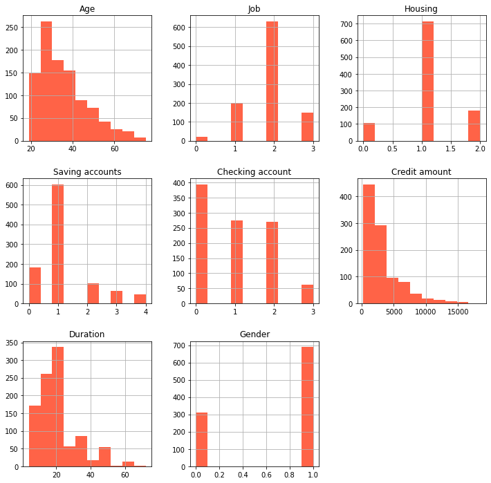

```python
# Plotting the histogram

df.hist(figsize = (12,12), color = "tomato")
```

## Interpretation:

```
- From the histogram, we can see that many variables are right skewed.
- The variables with right skew are: Age, Saving accounts, Credit amount, Duration. That gives us hints to not depend on the mean but to focus more on the median and mode, since the mean value might make the final decision quite bias.

- We have more date records related to the men than women. Based on the counting of the Gender variable.

- Missing values in the checking_account variable are more than the rest of the correct values. It's a serious problem I need to pay a close attention to it.

- Skilled individuals are the most figure welling to apply for loans, that's good indicator for the risk assessment that I will create later on.
```

### 3.5 Checking the outliers visually then statistically

```python
# Creating the function to plot the numeric variables using Box Plot.

def box_plot(arg1, arg2, arg3, arg4):
    # Setting the graphs to be 4 plots at the same time
    fig, axes = plt.subplots(ncols=4, figsize=(20,15))

    # Measuring the correlationship between each variable and the Gender type:
    sns.boxplot( data=df, x='Gender', y=arg1,palette="Set3", orient='v', ax=axes[0])
    sns.boxplot( data=df, x='Gender', y=arg2, palette="Set3", orient='v', ax=axes[1])
    sns.boxplot( data=df, x='Gender', y=arg3, palette="Set3", orient='v', ax=axes[2])
    sns.boxplot( data=df, x='Gender', y=arg4, palette="Set3", orient='v', ax=axes[3])

    # Creating the title for the 4 graphs
    fig.suptitle('Gender Characteristics with Numeric Variables', fontsize = 20)

    # Highlighting the fontsize
    axes[0].set_ylabel(arg1,fontsize = 20)
    axes[1].set_ylabel(arg2,fontsize = 20)
    axes[2].set_ylabel(arg3, fontsize = 20)
    axes[3].set_ylabel(arg4, fontsize = 20)

    plt.show()
```

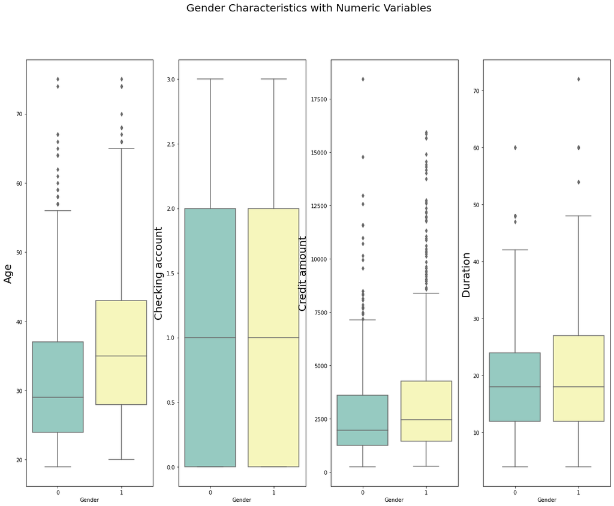

```python
box_plot("Age","Checking account","Credit amount","Duration")
```

## Interpretation:

```
- Graph (1) = Gender vs Age =
    - For men: we see that the average age that seek loans is above 35 years.
    - For women: we see that the average age that seek loans is close to 30.
    - We have outliers both sides and in the next section, we will highlight them in more details.

- Graph (2) = Gender vs Checking_account =
    - For both men and women the mean value is 1.

- Graph (3) = Gender vs Credit amount =
    - For men: the avergae credit amount is 2500 unlike the women average credit amount is close 2000
    - As we can see there is a unusal record needs to be invesitgated in the women box plot the record is above 17500. So in the next section, we will hgihlight the value with respect to the other observations in the dataframe.Then we will create a range of other individuals that have similar age, credit amount to decide whether to delete it or keep it.

- Graph (4) = Gender vs Duration =
    - For both women and men they have the avergae baseline for Duration which close to 20.
    - Then again, unusual record from the men side that's above 70. And I will invesitgate that one too.
```

```python
# Checking the first graph [0 0] from the previous Box plot.

df[df["Age"] > 70]
```

|  | Age | Job | Housing | Saving accounts | Checking account | Credit amount | Duration | Purpose | Gender |
| --- | --- | --- | --- | --- | --- | --- | --- | --- | --- |
| 186 | 74 | 3 | 0 | 1 | 2 | 5129 | 9 | car | 0 |
| 330 | 75 | 3 | 0 | 1 | 1 | 6615 | 24 | car | 1 |
| 430 | 74 | 1 | 1 | 1 | 0 | 3448 | 5 | business | 1 |
| 536 | 75 | 3 | 1 | 0 | 1 | 1374 | 6 | car | 0 |
| 606 | 74 | 3 | 1 | 1 | 0 | 4526 | 24 | business | 1 |
| 756 | 74 | 0 | 1 | 1 | 3 | 1299 | 6 | car | 1 |

```
Since this individual (index:756) is 74 years old, no job, with significant low credit amount. I have decided to eliminate this possible wrong typo from the system.
```

```python
# Drop the unusual record, since this individual is 74 years old, no job, with significant low credit amount.

df = df.drop(756).reset_index()
df.drop("index", axis=1,inplace=True)
```

```python
df.head(2)
```

|  | Age | Job | Housing | Saving accounts | Checking account | Credit amount | Duration | Purpose | Gender |
| --- | --- | --- | --- | --- | --- | --- | --- | --- | --- |
| 0 | 67 | 2 | 1 | 0 | 1 | 1169 | 6 | radio/TV | 1 |
| 1 | 22 | 2 | 1 | 1 | 2 | 5951 | 48 | radio/TV | 0 |

```
Based on the previous Box plot, we can see a possible outlier, as there are a record above 17500 in the credit amount. So first I will investigate this observation then invesitgate the range of these records between the age 30 to 40 to see if that's a rational trend. Or it's insignificant to have such an observation.
```

```python
# Checking the possible outlier:

df[df["Credit amount"] > 17500]
```

|  | Age | Job | Housing | Saving accounts | Checking account | Credit amount | Duration | Purpose | Gender |
| --- | --- | --- | --- | --- | --- | --- | --- | --- | --- |
| 914 | 32 | 3 | 1 | 1 | 2 | 18424 | 48 | vacation/others | 0 |

```python
# Check the observation range, meaning check other individuals in the same age pool,
#have multiple job skills and similar credit amount.

df[(df["Age"] > 30) & (df["Age"] < 40) & (df["Credit amount"] > 7500)]
```

|  | Age | Job | Housing | Saving accounts | Checking account | Credit amount | Duration | Purpose | Gender |
| --- | --- | --- | --- | --- | --- | --- | --- | --- | --- |
| 5 | 35 | 1 | 0 | 0 | 0 | 9055 | 36 | education | 1 |
| 57 | 31 | 2 | 1 | 1 | 0 | 9566 | 36 | radio/TV | 0 |
| 78 | 39 | 1 | 1 | 0 | 0 | 9436 | 54 | car | 1 |
| 105 | 39 | 3 | 1 | 1 | 2 | 11938 | 24 | vacation/others | 1 |
| 205 | 38 | 3 | 0 | 1 | 1 | 10623 | 30 | car | 1 |
| 272 | 36 | 3 | 0 | 0 | 2 | 12169 | 48 | car | 1 |
| 274 | 34 | 1 | 1 | 1 | 1 | 11998 | 30 | repairs | 1 |
| 285 | 35 | 1 | 1 | 1 | 1 | 10722 | 47 | car | 0 |
| 287 | 31 | 3 | 0 | 2 | 2 | 7582 | 48 | vacation/others | 1 |
| 375 | 37 | 2 | 2 | 1 | 1 | 7685 | 48 | business | 0 |
| 381 | 38 | 3 | 0 | 1 | 2 | 12976 | 18 | car | 0 |
| 395 | 32 | 2 | 2 | 2 | 2 | 11760 | 39 | education | 1 |
| 549 | 35 | 2 | 0 | 0 | 0 | 8858 | 48 | car | 1 |
| 563 | 37 | 2 | 0 | 0 | 2 | 12389 | 36 | car | 1 |
| 657 | 37 | 2 | 1 | 0 | 0 | 10222 | 48 | radio/TV | 1 |
| 684 | 31 | 1 | 1 | 2 | 2 | 9857 | 36 | business | 1 |
| 879 | 38 | 3 | 1 | 1 | 0 | 7814 | 24 | car | 1 |
| 894 | 31 | 3 | 1 | 0 | 0 | 8947 | 36 | car | 1 |
| 914 | 32 | 3 | 1 | 1 | 2 | 18424 | 48 | vacation/others | 0 |
| 920 | 37 | 3 | 1 | 3 | 0 | 12749 | 48 | radio/TV | 1 |
| 926 | 39 | 2 | 0 | 1 | 1 | 10297 | 48 | car | 1 |

```python
df = df.drop(914).reset_index()
df.drop("index", axis=1,inplace=True)
```

[output not shown]

```python
df[(df["Duration"] > 55) & (df["Age"] < 30)]
```

|  | Age | Job | Housing | Saving accounts | Checking account | Credit amount | Duration | Purpose | Gender |
| --- | --- | --- | --- | --- | --- | --- | --- | --- | --- |
| 134 | 21 | 2 | 1 | 2 | 0 | 10144 | 60 | radio/TV | 0 |
| 255 | 27 | 1 | 1 | 0 | 2 | 7418 | 60 | radio/TV | 1 |
| 332 | 24 | 3 | 1 | 2 | 2 | 7408 | 60 | car | 0 |
| 616 | 27 | 3 | 0 | 0 | 2 | 9157 | 60 | radio/TV | 1 |
| 637 | 21 | 2 | 1 | 1 | 0 | 15653 | 60 | radio/TV | 1 |
| 677 | 24 | 2 | 1 | 2 | 2 | 5595 | 72 | radio/TV | 1 |
| 714 | 27 | 3 | 1 | 1 | 2 | 14027 | 60 | car | 1 |

```
After creating a range for individuals between the age 20 to 30, and have Duration period of more than 55, we can see that the unusual observation fit singificently among them, so I can't exclude the value.
```

### 3.6 Essential Explorations and Their Interpretations

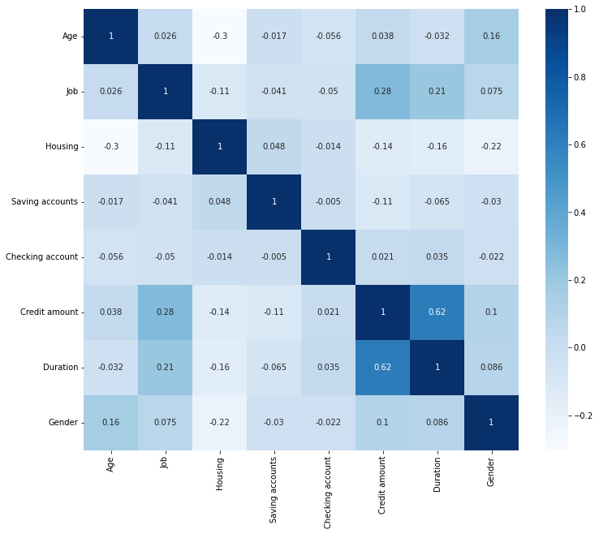

```python
# Heatmap

plt.figure(figsize = (12,10))
sns.heatmap(df.corr(), annot = True, cmap ="Blues")
```

## Interpretation:

```
- Heatmap represents the correlation between the variables of the dataframe.
- Some variables have positive/negative correlation with each other such as:
    - Age: Positive correlation with Gender and negative correlation with Housing.
    - Job: Positive correlation with Credit_amount then Duration.
    - Housing: Negative correlation with Age and Job skills.
    - Saving accounts: Negative correlation with credit amount.
    - Credit amount: Strong positive correlation with Duration and positive correlation with Job and negative correlation with Saving accounts.


- These relationships will help me later while approaching my analysis.
```

```python
# Highlight the value counts in order to set the labels.

df["Job"].value_counts()
```

```
2    630
1    200
3    147
0     21
Name: Job, dtype: int64
```

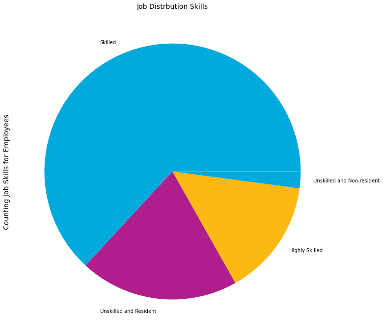

```python
# Plotting the Pie chart

df["Job"].value_counts().plot.pie(labels = ["Skilled", "Unskilled and Resident","Highly Skilled", "Unskilled and Non-resident"], figsize = (12,12), colors = ["#00A9DC", "#B01E8D", "#FDB812"])

plt.title("Job Distrbution Skills", fontsize = 14)
plt.ylabel("Counting Job Skills for Employees", fontsize = 14)

plt.show()

# https://www.w3schools.com/python/matplotlib_pie_charts.asp
```

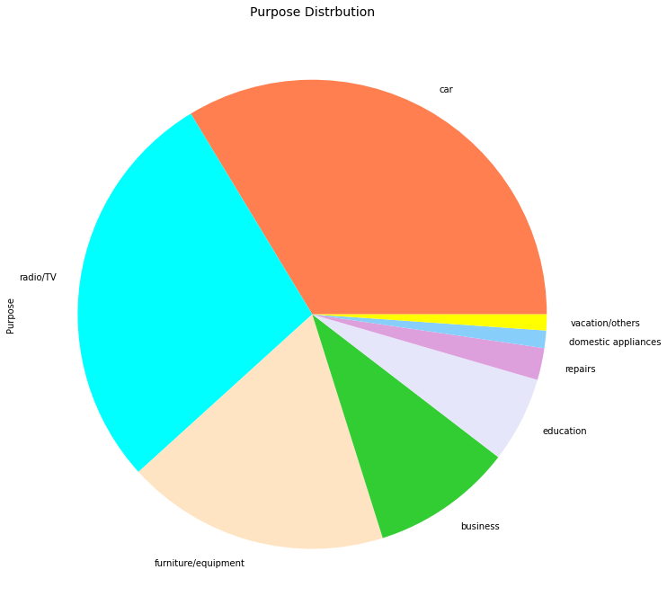

```python
# Plotting the Pie chart

df["Purpose"].value_counts().plot.pie(figsize = (12,12), colors = ("coral", "cyan", "bisque", "limegreen", "lavender", "plum","lightskyblue", "yellow"))

plt.title("Purpose Distrbution", fontsize = 14)

plt.show()

# https://www.w3schools.com/python/matplotlib_pie_charts.asp
```

## Interpretation:

```
- From the previous two pie plot, we conclude that for the Job skills applications we see the most visiable feature is skilled individuals followed by the Non-skilled but resident feature.
- When it comes to the Purpose the loans for; we see the most visiable reason is for car, then radio/TV then furniture/equipment.
```

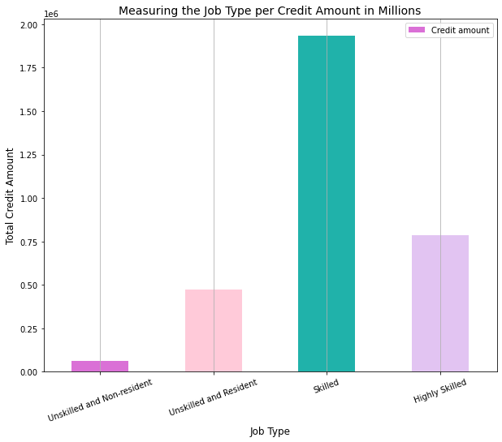

```python
# Plotting the bar plot

df.groupby("Job")["Credit amount"].sum().plot.bar(figsize = (10,8), color = ["#DA70D6", "#ffcad9", "#20b2aa", "#e2c4f2"])

# Make sure it's well-interrpreted

plt.title("Measuring the Job Type per Credit Amount in Millions", fontsize=14)
plt.ylabel("Total Credit Amount", fontsize = 12)
plt.xlabel("Job Type", fontsize=12)

plt.xticks([0,1,2,3],["Unskilled and Non-resident", "Unskilled and Resident", "Skilled","Highly Skilled"], rotation=20, fontsize=10)
plt.grid(axis="x")
plt.legend()
plt.show()

# https://matplotlib.org/stable/api/_as_gen/matplotlib.pyplot.xticks.html
```

## Interpretation:

```
- We can identifiy that the total credit amount for skilled people is close to 2 millions. Which might be related to their jobs and salaries followed by the highly-skilled. That gives us insight that the education variable if it was exist is a direct reason on the total amount. We could have created a hypothesis testing to check this potential before we create the classification models.
```

### 3.7 Use KNN (Regression) in Predicting the Missing Values for Saving_accounts & Checking_accounts

## Detailed Approach on handling the missing values using KNN Regression:

K-Nearest Neighbor regressor is a technique can be used as an imputation method to predict the missing values. It's executed by measuring the ditsance between every data node and the other then pick the shortest distance and after calculating the distance matrix using the next equation:

## $d_{ij}=\sqrt{\sum_{y=1}^{p}(x_{iy}^{\prime}-x_{jy}^{\prime})^{2}}$

Then computing the missing valuse under Y_prediction label using the next equation:

## $V_{ij}=\frac{1}{k}\sqrt{\sum_{i=1}^{k}w_{i}x_{ij}}$

The detailed mathmatical interpretation is descibed in well-detailed in the IEEE paper [1,2].

### Measuring the ratios of the missing values to identify the effect on the overall dataframe:

```python
#Ratio of mussing data fro Saving accounts & Checking accounts

print("The Ratio of Missing Values in the Saving Accounts Variable is = ", (df["Saving accounts"] == 0).sum()/1000, "* 100")
print("The Ratio of Missing Values in the Checking Accounts Variable is = ", (df["Checking account"] == 0).sum()/1000, "* 100")
```

```
The Ratio of Missing Values in the Saving Accounts Variable is =  0.183 * 100
The Ratio of Missing Values in the Checking Accounts Variable is =  0.394 * 100
```

## Interpretation:

**First, drop the Purpose variable since it's categorical column, and it will generate an error later on.**

```python
df.drop("Purpose", axis=1, inplace=True)
```

**Second, split the dataframe based on the "Saving Accounts" variable the values = 0 which are the missing variables, I will label them under X_test_saving_data. And the normal variables that represent correct data recording will be under the X_train_saving_data.**

```python
X_test_saving_data = df[df["Saving accounts"] == 0]
X_test_saving_data.head(2)
```

|  | Age | Job | Housing | Saving accounts | Checking account | Credit amount | Duration | Gender |
| --- | --- | --- | --- | --- | --- | --- | --- | --- |
| 0 | 67 | 2 | 1 | 0 | 1 | 1169 | 6 | 1 |
| 5 | 35 | 1 | 0 | 0 | 0 | 9055 | 36 | 1 |

```python
# Checking the shape of X_test

X_test_saving_data.shape
```

```
(183, 8)
```

```python
# Wanted to make sure that the counting is accurate and I didn't miss any values.

1000-183
```

```
817
```

```python
# Exclude missing values from the training sub-set

X_train_saving_data = df.loc[~((df['Saving accounts'] == 0))]
X_train_saving_data.head(2)

# https://stackoverflow.com/questions/49841989/python-drop-value-0-row-in-specific-columns
```

|  | Age | Job | Housing | Saving accounts | Checking account | Credit amount | Duration | Gender |
| --- | --- | --- | --- | --- | --- | --- | --- | --- |
| 1 | 22 | 2 | 1 | 1 | 2 | 5951 | 48 | 0 |
| 2 | 49 | 1 | 1 | 1 | 0 | 2096 | 12 | 1 |

```python
# Checking the shape of X_train

X_train_saving_data.shape
```

```
(815, 8)
```

```python
# Use the X_train sub-set to highlight the values of y_train

y_train_saving_data = X_train_saving_data['Saving accounts']
y_train_saving_data.head(2)
```

```
1    1
2    1
Name: Saving accounts, dtype: int64
```

```python
# Checking the shape of y_train

y_train_saving_data.shape
```

```
(815,)
```

### 3.7.1 Building the KNN model for the Missing Values in the Saving Account

**I have created 4 groups since "Saving_account" variable contains 4 labels [Little, Moderate, Quite Rich, High Rich]**

```python
from sklearn.neighbors import KNeighborsClassifier

knn = KNeighborsClassifier(n_neighbors=4)

knn.fit(X_train_saving_data, y_train_saving_data)
```

```
KNeighborsClassifier(n_neighbors=4)
```

```python
# Generate the prediction values

y_predict = knn.predict(X_test_saving_data)
```

```python
# Output the values

print(y_predict)
```

```
[1 1 1 1 1 1 3 1 1 1 1 1 1 1 1 1 1 1 1 1 1 1 1 1 1 1 1 1 1 1 1 1 1 1 2 1 1
 3 1 1 1 1 1 1 1 1 1 1 1 1 1 1 1 1 1 1 1 1 1 1 1 1 1 1 1 2 1 1 1 1 1 1 1 1
 2 1 1 1 1 1 1 2 1 1 1 1 1 1 1 1 1 1 1 1 1 1 1 1 1 1 1 1 1 1 1 1 1 1 1 1 1
 1 1 1 1 1 1 1 1 1 1 1 2 1 1 1 1 1 4 1 1 1 1 1 1 1 1 1 1 1 1 1 1 1 1 1 1 1
 1 1 1 1 1 1 1 1 1 1 1 1 1 1 1 2 1 1 1 1 1 1 1 1 1 1 2 1 1 1 1 1 1 1 1]
```

```python
# Check the shape before concatenate the whole sub-set

y_predict.shape
```

```
(183,)
```

```python
# Concatenate the values back together

X_test_saving_data["Saving accounts"] = X_test_saving_data.loc[X_test_saving_data["Saving accounts"] == 0, "Saving accounts"] = y_predict

#https://stackoverflow.com/questions/61238384/replacing-values-in-pandas-dataframe-column-with-same-row-value-from-another-col
```

```python
# Check the printed values

X_test_saving_data.head(2)
```

|  | Age | Job | Housing | Saving accounts | Checking account | Credit amount | Duration | Gender |
| --- | --- | --- | --- | --- | --- | --- | --- | --- |
| 0 | 67 | 2 | 1 | 1 | 1 | 1169 | 6 | 1 |
| 5 | 35 | 1 | 0 | 1 | 0 | 9055 | 36 | 1 |

```python
# Make sure I have omitted the 0 values which represent the missing values

X_test_saving_data["Saving accounts"].unique()
```

```
array([1, 3, 2, 4])
```

```python
X_test_saving_data.head(2)
```

|  | Age | Job | Housing | Saving accounts | Checking account | Credit amount | Duration | Gender |
| --- | --- | --- | --- | --- | --- | --- | --- | --- |
| 0 | 67 | 2 | 1 | 1 | 1 | 1169 | 6 | 1 |
| 5 | 35 | 1 | 0 | 1 | 0 | 9055 | 36 | 1 |

```python
# Counting the unique values in the column

X_test_saving_data["Saving accounts"].value_counts()
```

```
1    173
2      7
3      2
4      1
Name: Saving accounts, dtype: int64
```

```python
X_train_saving_data["Saving accounts"].value_counts()
```

```
1    601
2    103
3     63
4     48
Name: Saving accounts, dtype: int64
```

```python
print(173+603)
print(7+103)
print(2+63)
print(1+48)
```

```
776
110
65
49
```

```python
df00 = pd.concat([X_train_saving_data, X_test_saving_data], 0, ignore_index=True)


# https://stackoverflow.com/questions/46269804/concatenating-dataframes-on-a-common-index
```

```python
df00.head(2)
```

|  | Age | Job | Housing | Saving accounts | Checking account | Credit amount | Duration | Gender |
| --- | --- | --- | --- | --- | --- | --- | --- | --- |
| 0 | 22 | 2 | 1 | 1 | 2 | 5951 | 48 | 0 |
| 1 | 49 | 1 | 1 | 1 | 0 | 2096 | 12 | 1 |

```python
df00["Saving accounts"].value_counts()
```

```
1    774
2    110
3     65
4     49
Name: Saving accounts, dtype: int64
```

### 3.7.2 Building the KNN model for the Missing Values in the Checking Account

```python
### Let's do the Checking account too:

df["Checking account"].unique()
```

```
array([1, 2, 0, 3])
```

```python
# Highlight the missing values in the column Checking account

X_test_saving_data0 = df[df["Checking account"] == 0]
X_test_saving_data0.head(2)
```

|  | Age | Job | Housing | Saving accounts | Checking account | Credit amount | Duration | Gender |
| --- | --- | --- | --- | --- | --- | --- | --- | --- |
| 2 | 49 | 1 | 1 | 1 | 0 | 2096 | 12 | 1 |
| 5 | 35 | 1 | 0 | 0 | 0 | 9055 | 36 | 1 |

```python
# Check the shape of the new sub-set, as it's usually generate an error in the steps followed if it's done incorrectly

X_test_saving_data0.shape
```

```
(394, 8)
```

```python
# Hightlight the non-zero values in the checking account

X_train_saving_data0 = df.loc[~((df['Checking account'] == 0))]
X_train_saving_data0.head(2)
```

|  | Age | Job | Housing | Saving accounts | Checking account | Credit amount | Duration | Gender |
| --- | --- | --- | --- | --- | --- | --- | --- | --- |
| 0 | 67 | 2 | 1 | 0 | 1 | 1169 | 6 | 1 |
| 1 | 22 | 2 | 1 | 1 | 2 | 5951 | 48 | 0 |

```python
# Check the sub-set shape

X_train_saving_data0.shape
```

```
(604, 8)
```

```python
# Generate the y-train sub-set

y_train_saving_data0 = X_train_saving_data0['Checking account']
y_train_saving_data0.head(2)
```

```
0    1
1    2
Name: Checking account, dtype: int64
```

```python
# Check the sub-set shape

y_train_saving_data0.shape
```

```
(604,)
```

```python
from sklearn.neighbors import KNeighborsClassifier

knn = KNeighborsClassifier(n_neighbors=3)

knn.fit(X_train_saving_data0, y_train_saving_data0)
```

```
KNeighborsClassifier(n_neighbors=3)
```

```python
# Creating the missing values as y_pred

y_pred = knn.predict(X_test_saving_data0)
```

```python
print(y_pred)
```

```
[3 2 2 1 1 1 1 2 1 3 2 2 2 1 1 2 1 1 1 2 1 1 1 1 1 1 1 2 2 2 2 2 1 1 2 1 2
 1 2 1 2 2 1 2 2 2 2 2 2 1 1 3 2 1 2 1 1 1 2 1 1 1 1 2 2 1 1 2 1 2 2 1 2 1
 2 2 1 1 1 2 1 2 3 1 1 2 2 1 1 1 2 1 1 2 1 1 2 1 2 1 1 2 2 1 2 2 1 1 1 1 2
 2 2 1 2 1 2 1 2 2 1 2 1 2 2 2 1 2 3 1 2 2 1 1 2 2 1 2 2 2 2 1 2 1 2 1 1 1
 1 1 2 1 1 2 1 2 1 1 1 1 1 1 2 2 2 1 2 2 3 1 2 1 1 1 1 2 2 2 2 1 1 1 1 1 2
 2 3 1 2 2 1 1 2 1 2 2 1 2 2 2 2 1 1 1 2 1 2 1 1 2 1 2 1 2 1 2 2 1 2 1 2 1
 1 2 3 1 1 2 2 2 1 1 2 2 1 1 2 1 2 1 2 2 1 1 2 1 1 2 1 1 2 2 1 1 1 1 2 1 2
 1 1 1 1 1 2 1 2 1 2 2 2 2 2 2 1 2 1 1 2 2 1 1 2 2 1 2 1 1 1 2 2 1 2 2 1 2
 1 1 1 1 2 2 1 2 1 1 2 2 2 1 1 1 2 1 2 1 2 1 2 1 1 1 2 1 2 1 1 2 1 1 1 1 2
 1 2 2 1 1 1 1 1 2 1 2 1 1 1 2 1 1 1 1 2 2 1 1 2 1 1 1 2 2 1 1 1 2 1 1 2 1
 1 2 1 1 2 2 2 1 1 1 1 2 1 2 2 2 1 2 1 2 2 1 1 1]
```

```python
# Check the sub-set shape

y_pred.shape
```

```
(394,)
```

```python
X_test_saving_data0["Checking account"] = X_test_saving_data0.loc[X_test_saving_data0["Checking account"] == 0, "Checking account"] = y_pred
```

```python
X_test_saving_data0["Checking account"].unique()
```

```
array([3, 2, 1])
```

```python
X_test_saving_data0["Checking account"].value_counts()
```

```
1    212
2    174
3      8
Name: Checking account, dtype: int64
```

```python
X_train_saving_data0["Checking account"].value_counts()
```

```
1    274
2    268
3     62
Name: Checking account, dtype: int64
```

```python
print(210+274)
print(176+269)
print(8+63)
```

```
484
445
71
```

```python
df0 = pd.concat([X_train_saving_data0, X_test_saving_data0], 0, ignore_index=True)
```

```python
df0["Checking account"].value_counts()
```

```
1    486
2    442
3     70
Name: Checking account, dtype: int64
```

### 3.7.3 Concatenate the Predicted Values from Both the Saving_accounts & Checking_accounts in the Original Dataframe "df"

```python
df["Checking_accounts"] = df0["Checking account"]
df["Saving_accounts"] = df00["Saving accounts"]
```

```python
df.head(2)
```

|  | Age | Job | Housing | Saving accounts | Checking account | Credit amount | Duration | Gender | Checking_accounts | Saving_accounts |
| --- | --- | --- | --- | --- | --- | --- | --- | --- | --- | --- |
| 0 | 67 | 2 | 1 | 0 | 1 | 1169 | 6 | 1 | 1 | 1 |
| 1 | 22 | 2 | 1 | 1 | 2 | 5951 | 48 | 0 | 2 | 1 |

```python
# Drop the original old columns

df.drop(["Saving accounts", "Checking account"], axis = 1, inplace = True)
```

```python
# Checking the D-type of the columns

df.info()
```

```
<class 'pandas.core.frame.DataFrame'>
RangeIndex: 998 entries, 0 to 997
Data columns (total 8 columns):
 #   Column             Non-Null Count  Dtype
---  ------             --------------  -----
 0   Age                998 non-null    int64
 1   Job                998 non-null    int64
 2   Housing            998 non-null    int64
 3   Credit amount      998 non-null    int64
 4   Duration           998 non-null    int64
 5   Gender             998 non-null    int64
 6   Checking_accounts  998 non-null    int64
 7   Saving_accounts    998 non-null    int64
dtypes: int64(8)
memory usage: 62.5 KB
```

```python
# Double check if there's any miss-calculations

df.isna().sum()
```

```
Age                  0
Job                  0
Housing              0
Credit amount        0
Duration             0
Gender               0
Checking_accounts    0
Saving_accounts      0
dtype: int64
```

## mission accomplished :)

### 3.8 Create Clustering Analysis to Create Risk Level

```python
x = df.iloc[:, :-1].values
y = df.iloc[:,-1].values

#checking the shape of the input and output features

print('Shape of the input features:', x.shape)
print('Shape of the output features:', y.shape)
```

```
Shape of the input features: (998, 7)
Shape of the output features: (998,)
```

```python
#spliting the features into train & test sets

from sklearn.model_selection import train_test_split
x_train, x_test, y_train, y_test = train_test_split(x,y, test_size = 0.30, random_state=100)
```

```python
#checking the shape of the training & test sets
print('Shape of the training patterns:', x_train.shape,y_train.shape)
print('Shape of the testing patterns:', x_test.shape,y_test.shape)
```

```
Shape of the training patterns: (698, 7) (698,)
Shape of the testing patterns: (300, 7) (300,)
```

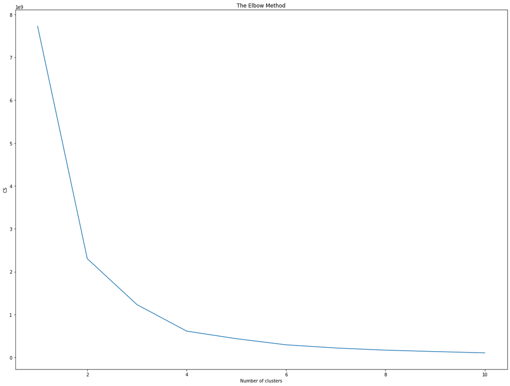

```python
from sklearn.cluster import KMeans
cs = []
for i in range(1, 11):
    kmeans = KMeans(n_clusters = i, init = 'k-means++', max_iter = 300, n_init = 10, random_state = 0)
    kmeans.fit(x)
    cs.append(kmeans.inertia_)

plt.figure(figsize = (20,15))

plt.plot(range(1, 11), cs)
plt.title('The Elbow Method')
plt.xlabel('Number of clusters')
plt.ylabel('CS')
plt.show()
```

```python
from sklearn.cluster import KMeans

kmeans = KMeans(n_clusters=3,random_state=0)

kmeans.fit(x)

labels = kmeans.labels_

# check how many of the samples were correctly labeled

correct_labels = sum(y == labels)

print("Result: %d out of %d samples were correctly labeled." % (correct_labels, y.size))

print('Accuracy score: {0:0.2f}'. format(correct_labels/float(y.size)))
```

```
Result: 600 out of 998 samples were correctly labeled.
Accuracy score: 0.60
```

```python
kmeans = KMeans(3)
kmeans.fit(x)
```

```
KMeans(n_clusters=3)
```

```python
identified_clusters = kmeans.fit_predict(x)
```

```python
identified_clusters = pd.DataFrame(identified_clusters)
identified_clusters.value_counts()
```

```
0    725
2    217
1     56
dtype: int64
```

```python
identified_clusters.columns = ["Risk_Level"]
```

```python
identified_clusters.head(2)
```

|  | Risk_Level |
| --- | --- |
| 0 | 0 |
| 1 | 2 |

```python
df["Risk Level"] = identified_clusters["Risk_Level"]
```

```python
df.head(2)
```

|  | Age | Job | Housing | Credit amount | Duration | Gender | Checking_accounts | Saving_accounts | Risk Level |
| --- | --- | --- | --- | --- | --- | --- | --- | --- | --- |
| 0 | 67 | 2 | 1 | 1169 | 6 | 1 | 1 | 1 | 0 |
| 1 | 22 | 2 | 1 | 5951 | 48 | 0 | 2 | 1 | 2 |

```python
#Re-order the columns in the df data frame

df = df[["Age", "Gender", "Job", "Housing", "Saving_accounts", "Checking_accounts", "Credit amount", "Duration",
        "Risk Level"]]
```

**Create Age Category using the recent Risk Level variable**

```python
data = df

# ["Youtth 19-29", "Adult 30-40", "MiddleAge 41-50", "Old 51-60", "VeryOld 61-76"]
```

```python
bins = [19,29,40,50,60,76]
labels = ["19-29", "30-40", "40-50", "51-60", "60-76"]
data['AgeGroup'] = pd.cut(data['Age'], bins=bins, labels=labels, right=False)
data.head(2)
```

|  | Age | Gender | Job | Housing | Saving_accounts | Checking_accounts | Credit amount | Duration | Risk Level | AgeGroup |
| --- | --- | --- | --- | --- | --- | --- | --- | --- | --- | --- |
| 0 | 67 | 1 | 2 | 1 | 1 | 1 | 1169 | 6 | 0 | 60-76 |
| 1 | 22 | 0 | 2 | 1 | 1 | 2 | 5951 | 48 | 2 | 19-29 |

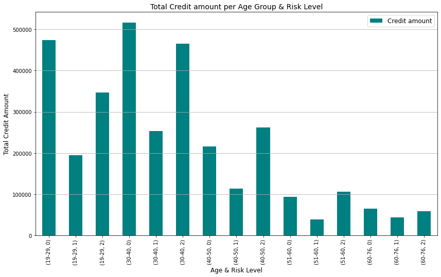

```python
data.groupby(["AgeGroup", "Risk Level"], sort = True)["Credit amount"].sum().plot.bar(figsize= (14,8), color = "teal")
plt.ylabel("Total Credit Amount", fontsize = 12)
plt.xlabel("Age & Risk Level", fontsize = 12)
plt.title("Total Credit amount per Age Group & Risk Level", fontsize = 14)

plt.legend(fontsize=12)
plt.grid(axis="y")
plt.show()
```

## Interpretation:

```
- I have used the recent "Risk Level" variable, in order to categorize the age values into decent groups and measure the interaction between the age groups and credit amount. To check the traffic of the applications.

- We can highlight main features in the previous bar plot as following:

    - Low Risk Level represents by 0: Individuals in the age group (30-40) recorded total credit amount of 500k, and in the age group (19-29) they recorded a total credit amount close to 500k. When it comes to the age group (40-50) recorded a toal credit amount above 200k.

    - Medium Risk Level represents by 1: According the previous plot the medium risk has decent ratios for all the age groups, maybe the peak point is for the age group (30-40) that recorded above 200k.

    - High Risk Level represents by 2: Age group (30-40) recorded total credit amount above 400k, and age group (19-29) recorded total credit amount above 300k. We might want to investigate the last section in more depth to see the other variables of the dataframe. As this category impact directly the decision of the stakeholders.
```

## Rationale Informing the Selection or Choice of the Three Machine Learning Techniques or Methods to Build and Train Models to Address the Problem

# The choosen classification techniques are:

```
1. Logistic Regression (LR)
2. Support Vector Machines (SVM)
3. Random Forest (RF)
```

## Those are based on multiple reasons:

[output not shown]

## Model Performance Evaluation Using the Logistic Regression Machine Learning Technique

## Main Characteristics:

Logistic Regression divides into binary classification and multi-label classification (Low Risk Level - Medium Risk Level - High Risk Level), and the second one is what I will implement later on in this file.

One of the main characteristic in LR is that based on probability rules and it uses Sigmiod function to not be restricted in the range of 0 and 1.

## How it works:

Simiply, linear regression rules apply, so we have a dependent variable and multiple independent variables and we will classify/predict the unique values of the dependent variable using the independent variables.

## What's the statistical approach based on:

The following is the LR equation:

## $sigma(z)=\frac{1}{1+e^{-z}}$

The Sigmiod equation is: (where n>=1)

## $sigma(z)=\frac{1}{1+e^{-nz}}$

However, while optimization approach we have to make the error function (it's the function of regression coefficients) reach the smaller amount as it reflects on iteration numbers and the runtime of the whole algorithms.

The error function is:

## $Y= \frac{1}{2}(y^{\prime}-y)^{2}$

[6]

## Limitation of this method:

- LR assumes there's no multicollinearity in the altercation of independent features.
- This technique is ideal for non-noisy data, and the improved methods in deep learning or neural network can overcome this classic mdethod.

## Splitting the dataframe into train & test subsets for LR

```python
# selecting features:


X = df[["Age", "Gender", "Job", "Housing", "Credit amount", "Duration"]]
y = df["Risk Level"]
```

```python
# split X and y into training and testing sets
from sklearn.model_selection import train_test_split

X_train, X_test, y_train, y_test = train_test_split(X,y, test_size = 0.25, random_state=100)
```

```python
# Import the requiored libraries

from sklearn.metrics import classification_report
from sklearn.metrics import confusion_matrix
from sklearn.metrics import accuracy_score
```

```python
from sklearn.linear_model import LogisticRegression

Logistic_classifier_clf = LogisticRegression()
print(Logistic_classifier_clf.fit(X_train, y_train))

Logistic_classifier_predict = Logistic_classifier_clf.predict(X_test)
```

```
LogisticRegression()
```

```python
print("The Accuracy Percentage for Logistic Regression Prediction is: ", round(accuracy_score(Logistic_classifier_predict, y_test),5)*100, "%")
```

```
The Accuracy Percentage for Logistic Regression Prediction is:  92.4 %
```

**92.40% is good indicator but we will try to improve this value before creating the ROC Curve.**

## Creating the Classification Report for LR

```python
print("The Logistic Regression Classification Report")
target_names = ['Low Risk Level', "Medium Risk", 'High Risk Level']
print(classification_report(Logistic_classifier_predict, y_test, target_names=target_names))
```

```
The Logistic Regression Classification Report
                 precision    recall  f1-score   support

 Low Risk Level       0.96      0.97      0.96       177
    Medium Risk       0.79      0.85      0.81        13
High Risk Level       0.86      0.82      0.84        60

       accuracy                           0.92       250
      macro avg       0.87      0.88      0.87       250
   weighted avg       0.92      0.92      0.92       250
```

## Creating the Confusion Matrix for LR

```python
LR_Confusion_matrix = confusion_matrix(Logistic_classifier_predict, y_test)
print(LR_Confusion_matrix)
```

```
[[171   0   6]
 [  0  11   2]
 [  8   3  49]]
```

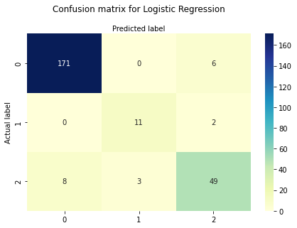

```python
class_names=[0,1] # name  of classes
fig, ax = plt.subplots()
tick_marks = np.arange(len(class_names))
plt.xticks(tick_marks, class_names)
plt.yticks(tick_marks, class_names)
# create heatmap
sns.heatmap(pd.DataFrame(LR_Confusion_matrix), annot=True, cmap="YlGnBu" ,fmt='g')
ax.xaxis.set_label_position("top")
plt.tight_layout()
plt.title('Confusion matrix for Logistic Regression', y=1.1)
plt.ylabel('Actual label')
plt.xlabel('Predicted label');
```

**As we can see here: TP (True Positive) are 171 - 11 - 49.**

## Creating the ROC Curve for LR

```python
#Calculate the y_score
LR_y_score = Logistic_classifier_clf.fit(X_train, y_train).predict_proba(X_test)
```

```python
from sklearn.preprocessing import label_binarize

#Binarize the output
LR_y_test_bin = label_binarize(y_test, classes=[0,1,2])
n_classes = LR_y_test_bin.shape[1]
```

```
AUC for Class 1: 0.9676607128806357
AUC for Class 2: 0.9909200968523002
AUC for Class 3: 0.949186437596582
```

[figure not shown]

```python
from sklearn import metrics

fpr = dict()
tpr = dict()
roc_auc = dict()

for i in range(n_classes):
  fpr[i], tpr[i], _ = metrics.roc_curve(LR_y_test_bin[:, i], LR_y_score[:, i])
  plt.plot(fpr[i], tpr[i], color='coral', lw=2)
  print('AUC for Class {}: {}'.format(i+1, metrics.auc(fpr[i], tpr[i])))

plt.plot([0, 1], [0, 1], color='navy', lw=2, linestyle='--')
plt.xlim([0.0, 1.0])
plt.ylim([0.0, 1.05])
plt.xlabel('False Positive Rate')
plt.ylabel('True Positive Rate')
plt.title('ROC for Random Forest')
plt.show()
```

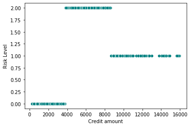

```python
# Create a scatter chart to see the baseline for each risk level

sns.scatterplot(x="Credit amount", y="Risk Level", data=df, color='teal')
```

## Model Performance Evaluation Using the Support Vector Machines (SVM) Machine Learning Technique

## How SVM works in classification:

SVM is a supervised machine learning algorithm that can be implemented for classification problems or regression problems. It's based on a method known as Linear Kernel which transforms the data values and looks for an optimal boundary between the potential outcomes. [3,4,5]

## Statistical Equation behind this technique:

## $f(x)=Sgn\left[\sum\limits_{i=1}^{n}\alpha_{i}y_{i}K(x_{i},x)+b\right]$

```python
from sklearn.svm import SVC


SVM_classifier_clf = SVC(kernel='linear', probability=True)
print(SVM_classifier_clf.fit(X_train, y_train))


SVM_classifier_predict = SVM_classifier_clf.predict(X_test)
```

```
SVC(kernel='linear', probability=True)
```

```python
print("The Accuracy Percentage for SVM Prediction is: ", round(accuracy_score(SVM_classifier_predict, y_test),5)*100, "%")
```

```
The Accuracy Percentage for SVM Prediction is:  99.6 %
```

```python
print("The SVM Classification Report")
target_names = ['Low Risk Level', "Medium Risk", 'High Risk Level']
print(classification_report(SVM_classifier_predict, y_test, target_names=target_names))
```

```
The SVM Classification Report
                 precision    recall  f1-score   support

 Low Risk Level       1.00      1.00      1.00       179
    Medium Risk       0.93      1.00      0.96        13
High Risk Level       1.00      0.98      0.99        58

       accuracy                           1.00       250
      macro avg       0.98      0.99      0.98       250
   weighted avg       1.00      1.00      1.00       250
```

**As we can see here that the precision for Low Risk Level is 100% unlike the Medium Risk Level 93%. However the F1-score which represents the interaction between the precision and recall ratio is pretty high for all the risk levels and from the range 0 to 9. We have the highest F1-score for SVM technique. This report proves that SVM mechanisim interact very well with this dataset despite the imbalanced, nosiy attributes.**

```python
SVM_Confusion_matrix = confusion_matrix(SVM_classifier_predict, y_test)
print(SVM_Confusion_matrix)
```

```
[[179   0   0]
 [  0  13   0]
 [  0   1  57]]
```

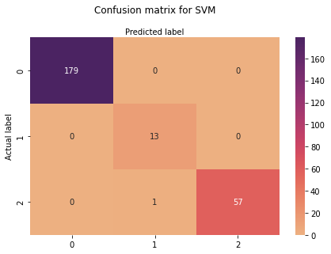

```python
class_names=[0,1] # name  of classes
fig, ax = plt.subplots()
tick_marks = np.arange(len(class_names))
plt.xticks(tick_marks, class_names)
plt.yticks(tick_marks, class_names)
# create heatmap
sns.heatmap(pd.DataFrame(SVM_Confusion_matrix), annot=True, cmap="flare" ,fmt='g')
ax.xaxis.set_label_position("top")
plt.tight_layout()
plt.title('Confusion matrix for SVM', y=1.1)
plt.ylabel('Actual label')
plt.xlabel('Predicted label');
```

**As we can see here: TP (True Positive) are 179 - 13 - 57.**

```python
#Calculate the y_score
SVM_y_score = SVM_classifier_clf.fit(X_train, y_train).predict_proba(X_test)
```

```python
from sklearn.preprocessing import label_binarize

#Binarize the output
SVM_y_test_bin = label_binarize(y_test, classes=[0,1,2])
n_classes = SVM_y_test_bin.shape[1]
```

```
AUC for Class 1: 1.0
AUC for Class 2: 1.0
AUC for Class 3: 0.9998181983456049
```

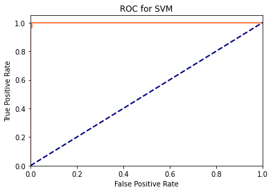

```python
fpr = dict()
tpr = dict()
roc_auc = dict()

for i in range(n_classes):
  fpr[i], tpr[i], _ = metrics.roc_curve(SVM_y_test_bin[:, i], SVM_y_score[:, i])
  plt.plot(fpr[i], tpr[i], color='coral', lw=2)
  print('AUC for Class {}: {}'.format(i+1, metrics.auc(fpr[i], tpr[i])))

plt.plot([0, 1], [0, 1], color='navy', lw=2, linestyle='--')
plt.xlim([0.0, 1.0])
plt.ylim([0.0, 1.05])
plt.xlabel('False Positive Rate')
plt.ylabel('True Positive Rate')
plt.title('ROC for SVM')
plt.show()
```

**As we can see here features for class 2 have been improved from 93% to 100%.**

## Model Performance Evaluation Using the Random Forest Machine Learning Technique

## How RF works in classification:

```python
# Building the RF model

from sklearn.ensemble import RandomForestClassifier

Random_Classifier_clf = RandomForestClassifier(n_estimators=100)

print(Random_Classifier_clf.fit(X_train, y_train))

Random_Classifier_predict = Random_Classifier_clf.predict(X_test)
```

```
RandomForestClassifier()
```

## Implementing the Features Importance in Random Forest

```python
feature_importance = pd.Series(Random_Classifier_clf.feature_importances_,
                               index=["Age", "Gender", "Job", "Housing", "Credit amount", "Duration"])

feature_importance = feature_importance.sort_values(ascending=False)
feature_importance = round(feature_importance*100,3)
feature_importance
```

```
Credit amount    83.658
Duration          9.674
Age               3.020
Job               1.982
Housing           1.273
Gender            0.391
dtype: float64
```

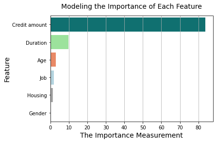

```python
sns.barplot(x=feature_importance, y=feature_importance.index, palette = ("teal", "lightgreen","coral", "lightblue", "darkgrey", "white"))

plt.title("Modeling the Importance of Each Feature", pad=15, fontsize = 14)
plt.xlabel("The Importance Measurement", fontsize=14)
plt.ylabel("Feature", fontsize=14)

plt.grid(axis="x")
plt.show()
```

## Interpretation:

```
- As we can see here that there are some crucial features (Credit amount & Duration) and other features we can eliminate them to improve our model.
```

## Redplot the Random Forest again after eliminating the unnecessary variables

```python
# selecting features:


X = df[["Credit amount", "Duration"]]
y = df["Risk Level"]
```

```python
# split X and y into training and testing sets
from sklearn.model_selection import train_test_split

X_train, X_test, y_train, y_test = train_test_split(X,y, test_size = 0.25, random_state=100)
```

```python
Random_Classifier_clf = RandomForestClassifier(n_estimators=100)
```

**Predicting the model**

```python
Random_Classifier_clf.fit(X_train, y_train)

Random_Classifier_predict = Random_Classifier_clf.predict(X_test)
```

**Measuring the accuracy of the model**

```python
print("The Accuracy Percentage for Random Forest Prediction is: ", round(accuracy_score(Random_Classifier_predict, y_test),5)*100, "%")
```

```
The Accuracy Percentage for Random Forest Prediction is:  99.2 %
```

## Creating the Random Forest Tree after deploying the feature importance technique

[output not shown]

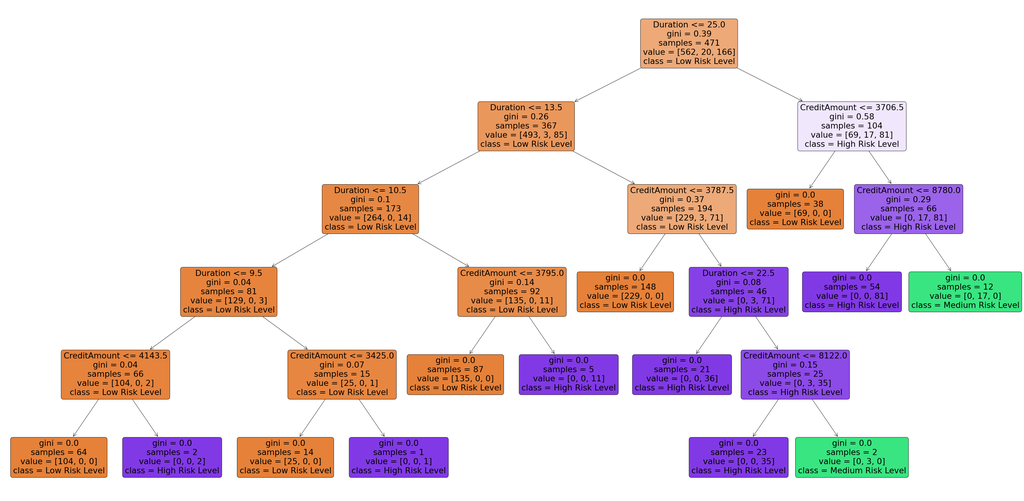

```python
from sklearn.tree import plot_tree

plt.figure(figsize=(60,30))
plot_tree(Random_Classifier_clf.estimators_[5],
         filled=True,feature_names=["CreditAmount", "Duration"],
         class_names=['Low Risk Level', "Medium Risk Level", 'High Risk Level'],
          rounded=True, proportion=False,precision=2)
```

## Interpretation:

[output not shown]

## Creating the Classification Report for RF

```python
print("The Random Forest Classification Report")
print(classification_report(Random_Classifier_predict, y_test, target_names=target_names))
```

```
The Random Forest Classification Report
                 precision    recall  f1-score   support

 Low Risk Level       1.00      1.00      1.00       179
    Medium Risk       0.86      1.00      0.92        12
High Risk Level       1.00      0.97      0.98        59

       accuracy                           0.99       250
      macro avg       0.95      0.99      0.97       250
   weighted avg       0.99      0.99      0.99       250
```

**As we can see here that the precision for Low & High Risk Level is 100% unlike the Medium Risk Level is 86% which pretty low compared the other two. On the other hand, the recall ratio is significant since the recall represents the percentage between the values of true positive to the total number of positive values.**

## Creating the Confusion Matrix for RF

```python
RF_Confusion_matrix = confusion_matrix(Random_Classifier_predict, y_test)
print(RF_Confusion_matrix)
```

```
[[179   0   0]
 [  0  12   0]
 [  0   2  57]]
```

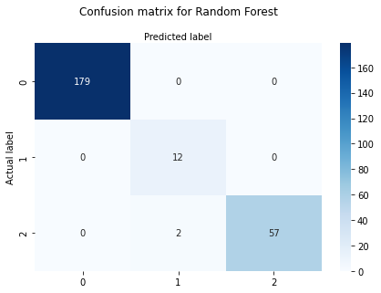

```python
class_names=[0,1] # name  of classes
fig, ax = plt.subplots()
tick_marks = np.arange(len(class_names))
plt.xticks(tick_marks, class_names)
plt.yticks(tick_marks, class_names)
# create heatmap
sns.heatmap(pd.DataFrame(RF_Confusion_matrix), annot=True, cmap="Blues" ,fmt='g')
ax.xaxis.set_label_position("top")
plt.tight_layout()
plt.title('Confusion matrix for Random Forest', y=1.1)
plt.ylabel('Actual label')
plt.xlabel('Predicted label');
```

## Creating the ROC Curve for RF

```python
#Calculate the y_score
RF_y_score = Random_Classifier_clf.fit(X_train, y_train).predict_proba(X_test)
```

```python
from sklearn.preprocessing import label_binarize

#Binarize the output
RF_y_test_bin = label_binarize(y_test, classes=[0,1,2])
n_classes = RF_y_test_bin.shape[1]
```

```
AUC for Class 1: 1.0
AUC for Class 2: 1.0
AUC for Class 3: 1.0
```

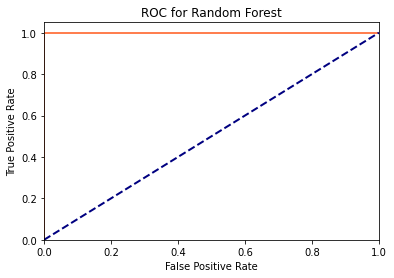

```python
fpr = dict()
tpr = dict()
roc_auc = dict()

for i in range(n_classes):
  fpr[i], tpr[i], _ = metrics.roc_curve(RF_y_test_bin[:, i], RF_y_score[:, i])
  plt.plot(fpr[i], tpr[i], color='coral', lw=2)
  print('AUC for Class {}: {}'.format(i+1, metrics.auc(fpr[i], tpr[i])))

plt.plot([0, 1], [0, 1], color='navy', lw=2, linestyle='--')
plt.xlim([0.0, 1.0])
plt.ylim([0.0, 1.05])
plt.xlabel('False Positive Rate')
plt.ylabel('True Positive Rate')
plt.title('ROC for Random Forest')
plt.show()
```

**As we can see here features have been improved from 86% for Medium Risk to 100%.**

## Comparisons between all Machine Learning Techniques or Methods

[output not shown]

```
The main differences between the Logistic Regression, Support Vector Machines and Random Forest is that the LR is linear model sesitive to noisy, imbalanced data. LR pays maximum ratios in normally distributed datasets. Unlike the SVM and RF models both aren't sensitive for such imbalanced, nosiy data.

Additionally While creating the ROC Curve, I have refined the features of the model and it paied off as you can see int he previous table. When it comes to the RF model, I have highlighted the features importance before creating the plot tree.

Based on the table above, we can see whether Support Vector Machines or Random Forest classification methods, both handle the data values more significant than the Logistic Regression. The ratios for accuracy which represents how accurate the traing subset is capable of predicting the testing subset by using the same modeling, and precision which represents how precise the model of generating the same values over and over again while deploying, recall which represents the ratio true positive compared to the all true positive in the data sampling. All the ratios are impressive. The most flexible classification techniques in order are SVM then RF and finally LR.
```

## Recommendations and Conclusions

Final Conclusion:

```
    - This dataset is rich in the observations and it might be so useful if there is a possability to add more records to create further analysis, such as hypothesis testing.

    - Where I have started in this dataframe was to create a new column to start classifying the variables in this dataframe. But to do that I had to refine my data values to make sure that there's no missing values/outliers/inconsistency. And the fastest, easiest way is to use imputation technique such as (mean, mode, median) however since the dataframe is skewed to the right I wanted more accurate precise results.

    - I have used machine learning to predict the missing values (K-Nearest Neighbor) method.

    - Then I have used clsutering (kmeans with distance calculations) to create a new column called Risk Level. Where I group all the observations in the dataframe with respect to this column. So this column becomes the dependent variable that depends on the original independent columns in the dataset.

    - Once I reach to this point, I have a solid dataframe to start my classification methods from Logistic Regression, Support Vector Machines and Random Forest.

    - Finally generating useful insight matrics to runa comparison between the different models. I have clarified the differences at the top while I explained why I chose those, then in every section.
```

## Academic Materials "IEEE Xplore & Books"

[1] S. Sen, M. N. Das and R. Chatterjee, "A Weighted kNN approach to estimate missing values," 2016 3rd International Conference on Signal Processing and Integrated Networks (SPIN), 2016, pp. 210-214, doi: 10.1109/SPIN.2016.7566690.

[2] Shahla Faisal, Gerhard Tutz, "Multiple imputation using nearest neighbor methods," Information Sciences, Volume 570, 2021, Pages 500-516, ISSN 0020-0255, doi: https://doi.org/10.1016/j.ins.2021.04.009.

[3] Yujun Yang, Jianping Li and Yimei Yang, "The research of the fast SVM classifier method," 2015 12th International Computer Conference on Wavelet Active Media Technology and Information Processing (ICCWAMTIP), 2015, pp. 121-124, doi: 10.1109/ICCWAMTIP.2015.7493959.

[4] J. Huang, J. Zhou and L. Zheng, "Support Vector Machine Classification Algorithm Based on Relief-F Feature Weighting," 2020 International Conference on Computer Engineering and Application (ICCEA), 2020, pp. 547-553, doi: 10.1109/ICCEA50009.2020.00121.

[5] Chen Junli and Jiao Licheng, "Classification mechanism of support vector machines," WCC 2000 - ICSP 2000. 2000 5th International Conference on Signal Processing Proceedings. 16th World Computer Congress 2000, 2000, pp. 1556-1559 vol.3, doi: 10.1109/ICOSP.2000.893396.

[6] X. Zou, Y. Hu, Z. Tian and K. Shen, "Logistic Regression Model Optimization and Case Analysis," 2019 IEEE 7th International Conference on Computer Science and Network Technology (ICCSNT), 2019, pp. 135-139, doi: 10.1109/ICCSNT47585.2019.8962457.

### Convert the Jupyter Notebook to PDF

```python
import pdfkit

options = {
'page-size': 'A4',
'margin-top': '0in',
'margin-right': '0in',
'margin-bottom': '0in',
'margin-left': '0in',
'encoding': "UTF-8",
'no-outline': None
}

# https://github.com/wkhtmltopdf/wkhtmltopdf/issues/2810
# https://pdfkit.org/docs/guide.pdf
# https://stackoverflow.com/questions/65991584/how-to-specify-pdf-page-size-using-pdfkit-in-python
```

```python
pdfkit.from_file('Rewan Emam - S21003259 -- ML ( Applied Machine Learning Project -- 24-10-2022).html',
                 'Rewan Emam - S21003259 -- ML ( Applied Machine Learning Project -- 24-10-2022).pdf',options=options)
```

```
True
```